# Projekt 2 - faza 1

16 maja 2016

## Rozkład najpopularniejszych słów w trakcie tygodnia

|  | 08 | 09 | 10 | 11 | 12 | 13 | 14 | 15 | 16 | 17 | 18 | 19 |
| --- | --- | --- | --- | --- | --- | --- | --- | --- | --- | --- | --- | --- |
| mieć | 47 | 30 | 49 | 68 | 35 | 35 | 38 | 54 | 43 | 35 | 48 | 41 |
| bank | 34 | 27 | 36 | 47 | 31 | 33 | 40 | 38 | 33 | 24 | 30 | 41 |
| ING | 30 | 16 | 37 | 48 | 25 | 25 | 38 | 26 | 27 | 35 | 23 | 20 |
| konto | 26 | 16 | 21 | 38 | 34 | 18 | 43 | 53 | 30 | 30 | 29 | 31 |
| karta | 32 | 26 | 40 | 35 | 49 | 26 | 33 | 46 | 22 | 10 | 35 | 52 |
| móc | 20 | 7 | 25 | 38 | 25 | 16 | 22 | 45 | 29 | 40 | 19 | 17 |
| klient | 17 | 9 | 23 | 27 | 10 | 14 | 25 | 14 | 22 | 15 | 18 | 14 |
| przelew | 15 | 12 | 20 | 26 | 15 | 17 | 34 | 27 | 19 | 6 | 19 | 7 |
| prosić | 21 | 16 | 14 | 28 | 16 | 20 | 11 | 23 | 21 | 17 | 14 | 12 |
| bankomat | 14 | 6 | 16 | 18 | 22 | 6 | 22 | 17 | 23 | 16 | 12 | 12 |

## Rozkład najpopularniejszych fraz w weekend

|  | 08 | 09 | 10 | 11 | 12 | 13 | 14 | 15 | 16 | 17 | 18 | 19 |
| --- | --- | --- | --- | --- | --- | --- | --- | --- | --- | --- | --- | --- |
| ING Bank Śląski | 8 | 4 | 14 | 19 | 5 | 9 | 8 | 5 | 10 | 4 | 9 | 2 |
| usługa ING | 1 | 2 | 2 | 2 | 1 | 4 | 1 | 1 | 2 | 1 | 0 | 2 |
| 32 357 00 10 | 2 | 1 | 2 | 1 | 2 | 3 | 2 | 2 | 5 | 2 | 2 | 4 |
| usługa ING BankOnLine | 1 | 2 | 2 | 2 | 1 | 5 | 1 | 2 | 2 | 1 | 0 | 2 |
| działać prawidłowo | 2 | 2 | 1 | 1 | 0 | 1 | 2 | 1 | 2 | 1 | 3 | 3 |
| ING BankOnLine | 6 | 1 | 3 | 6 | 1 | 2 | 5 | 1 | 3 | 1 | 3 | 2 |
| inny bank | 2 | 2 | 4 | 1 | 1 | 0 | 1 | 1 | 1 | 1 | 0 | 3 |
| aplikacja mobilny | 4 | 2 | 4 | 0 | 1 | 1 | 3 | 1 | 1 | 0 | 2 | 0 |
| oddział bank | 1 | 0 | 2 | 4 | 1 | 3 | 1 | 1 | 1 | 0 | 0 | 1 |
| bankowość internetowy | 1 | 2 | 0 | 2 | 0 | 0 | 0 | 0 | 0 | 2 | 4 | 2 |

## Najpopularniejsze frazy

|  | podstawa | ile_razy_bylo |
| --- | --- | --- |
| 1 | ING Bank Śląski | 1437 |
| 2 | usługa ING | 271 |
| 3 | 32 357 00 10 | 252 |
| 4 | usługa ING BankOnLine | 238 |
| 5 | działać prawidłowo | 223 |
| 6 | ING BankOnLine | 216 |
| 7 | inny bank | 197 |
| 8 | aplikacja mobilny | 194 |
| 9 | oddział bank | 179 |
| 10 | bankowość internetowy | 165 |

## Najpopularniejsze słowa

|  | podstawa | ile_razy_bylo |
| --- | --- | --- |
| 1 | mieć | 5052 |
| 2 | bank | 4419 |
| 3 | ING | 3695 |
| 4 | konto | 3537 |
| 5 | karta | 3191 |
| 6 | móc | 2526 |
| 7 | klient | 2038 |
| 8 | przelew | 1953 |
| 9 | prosić | 1913 |
| 10 | bankomat | 1770 |

## Analiza danych

- Mając przerobione dane, czas na próbę analizy.
- Czy zaobserwowane wypowiedzi są przypadkowe, czy też są spowodowane jakimś czynnikiem zewnętrznym?
- Porównywanie nowych obserwacji do posiadanych danych jest czasochłonne.
- Potrzebujemy metody, która pozwoli na szybkie sprawdzenie tego, czy ilość wystąpień słowa w danym zakresie czasu jest przypadkowa bez potrzeby odwoływania się do wszystkich danych.

## Rozkład Poissona

- Traktowanie wystąpień słowa jako kolejnych zdarzeń występujących z pewną częstotliwością.
- Jeśli ilość zaobserwowanych słów jest mało prawdopodobna, to coś może być nie tak.
- Średnia ilość wystąpień jest estymatorem parametru \(\lambda\).
- Problem z niezależnością zdarzeń.
- Estymacja średniej łącznie z dniami, w których słowo nie wystąpiło.
- Otrzymany rozkład empiryczny nie przypomina rozkładu Poissona.

## Przykładowy histogram

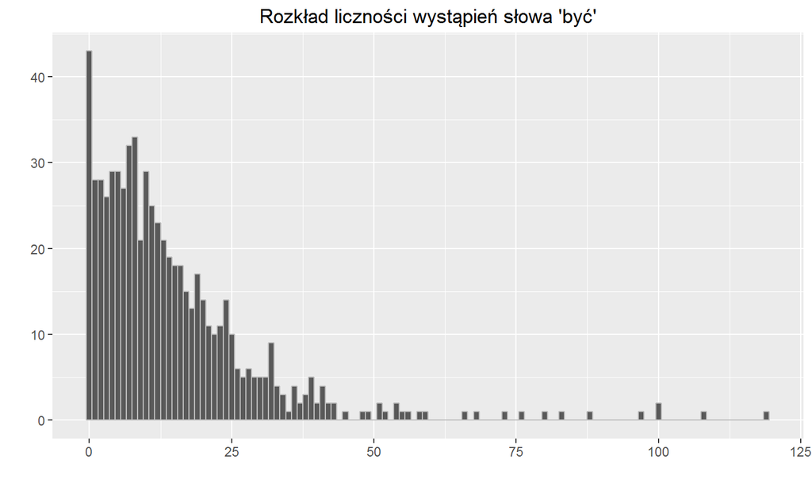

## Dystrybuanta empiryczna

- Bardziej uniwersalne podejście, nie wymaga specyfikowania rozkładu.
- Pozwala na szybkie sprawdzenie przypadkowości zaobserwowanych wystąpień słowa.
- Raz zbudowane funkcje zajmują mało miejsca.
- Pozwala na kalibrację progu, dla którego podejmujemy działanie.
- Stworzona na podstawie ilości wystąpień słowa w ciągu całego dnia.
- Zmniejszenie jednostki czasu pozwoli na szybsze reagowanie, ale też zmniejszy ilość danych na których zbudujemy dystrybuantę.

## Przykładowa dystrybuanta

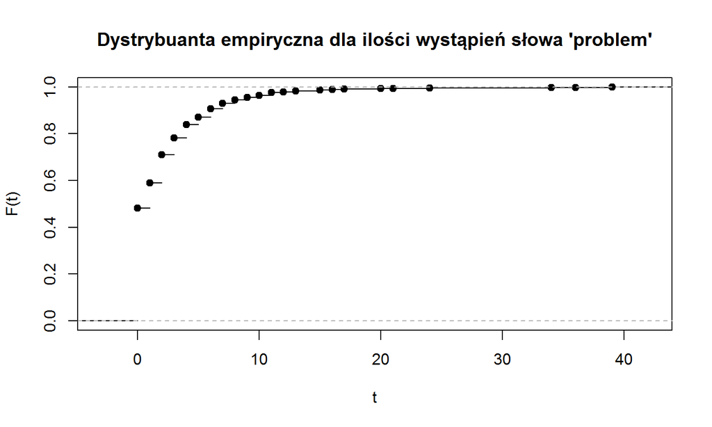

## Przykładowe zastosowanie

- Mając gotowe narzędzie testujemy je na otrzymanych danych.
- Szukamy tych dni, dla których wartość dystrybuanty była większa niż 0.95.
- W tym przypadku jest to równoważne wybraniu 5 % dni o największej ilości wystąpień słowa "problem".
- Dla nowych obserwacji (na przykład ściąganych codziennie postów) działa to już tak jak powinno.
- Kolejne slajdy zawierają krótki opis wykrytych awarii i przykładowe posty.

## 8, 11 listopada 2013 r.

- Problemy z wypłatami z bankomatów.
- "Witam 8 11 2013 roku próbowałem pobrać pieniądze z bankomatu euronet,niestety pieniędzy nie dostałem a kwota 1000zł została zablokowana i miała być zwrócona na konto,jednak wczoraj wieczorem zobaczyłem ze kwota jest zaksięgowana.Jak długo bedę czekać na moje pieniądze??"
- "Mam to samo. Pieniędzy Euronet nie wypłacił, ING zaksięgował. Jestem załamany tą sytuacją."
- "W dniu 8.11.2013 w godzinach popołudniowych w bankomatach sieci Euronet i PKO BP występowały problemy techniczne ze zrealizowaniem transakcji. Problem braku możliwości wypłaty pieniędzy z tych bankomatów przez naszych klientów nie był spowodowany przez ING Bank Śląski."

## 23, 24, 27 listopada 2014 r.

- Awaria systemu internetowego.
- "Nic nie działa nie można się zalogować - nie ma na ten temat żadnej informacji dla klienta, infolinia każe czekać w nieskończoność"
- "Wielki problem z logowaniem się na ING ! "
- "Dziś wieczorem wystąpiły niespodziewane problemy z dostępem do systemu. Nie mają one w związku z planowaną przerwą techniczną w weekend. Obecnie można zalogować się do systemu i wykonywać przelewy oraz sprawdzić stan konta. Przepraszamy za utrudnienia."

## 27 lipca 2015 r.

- Awaria systemu internetowego oraz wpłatomatów.
- "Cały czas mam "Błąd połączenia z serwerem." po próbie wpisania hasła w aplikacji mobilnej. :-( "
- "czas mija a problem dalej nie rozwiazany, nie mogłem sie dzisuaj po południu dostać na rachunek maklerski , poniosłem straty, kto mi je zrekompensuje?"
- "Dziękujemy za zgłoszenie. Aktualnie występują chwilowe problemy techniczne, ale stale pracujemy nad usunięciem błędów. Prosimy o cierpliwość."

## 10 lutego 2016 r.

- Awaria systemu wysyłającego SMSy z kodami autoryzacyjnymi.
- "Witam serdecznie, czy mają Państwo obecnie jakieś problemy techniczne z serwisem SMS ? Kody autoryzacyjne dla przelewów internetowych wysyłane są z godzinnym opóźnieniem co uniemożliwia ich wykonywanie. "
- "Rzeczywiście, obecnie mamy problemy techniczne, ale już pracujemy nad ich rozwiązaniem. Przepraszamy za utrudnienia."